# scPyviewer API Tutorial

**scPyviewer** is a Python-native viewer and programmatic API for single-cell AnnData (`.h5ad`) objects.  
This notebook walks through every API function with runnable examples.

## Installation

```
pip install scPyviewer          # core (no Streamlit)
pip install 'scPyviewer[all]'   # core + viewer + clustering + xlsx export
```

## Contents

1. Setup & toy dataset
2. Load a dataset
3. Global style
4. `plot_embedding` — UMAP / t-SNE scatter
5. `plot_multigene` — multi-gene expression grid
6. `plot_violin` — violin / box plot
7. `plot_dotplot` — dot plot
8. `plot_composition` — stacked bar
9. Table functions
10. Export figures & tables
11. Publication-quality workflow
12. `plot_heatmap` — gene × group heatmap
13. `plot_matrixplot` — mean expression matrix
14. `plot_stacked_violin` — multi-gene violin stack
15. `plot_tracksplot` — single-cell expression tracks
16. `plot_correlation` — inter-group correlation heatmap

## 1 · Setup & toy dataset

We build a small synthetic AnnData so the notebook runs without downloading data.  
Replace `tmp_path` with your own `*.prepared.h5ad` when working with real data.

```python
%matplotlib inline
import warnings
warnings.filterwarnings("ignore")

import numpy as np
import pandas as pd
import anndata as ad
import scipy.sparse as sp
import tempfile, os
import matplotlib.pyplot as plt
import matplotlib
matplotlib.rcParams['figure.dpi'] = 100   # notebook display DPI

# ── build a synthetic 200-cell × 80-gene AnnData ──────────────────────────
rng = np.random.default_rng(42)
n_cells, n_genes = 200, 80
gene_names = [f"Gene{i:03d}" for i in range(n_genes)]

counts = (
    sp.random(n_cells, n_genes, density=0.35, format="csr", random_state=42)
    .toarray() * 12
).astype(np.float32)
lognorm = np.log1p(
    counts / np.clip(counts.sum(axis=1, keepdims=True), 1, None) * 1e4
).astype(np.float32)

cell_types = np.array(
    ["T cell"] * 60 + ["B cell"] * 50 + ["NK cell"] * 40 + ["Monocyte"] * 50
)
batch = np.array(["Sample_A"] * 100 + ["Sample_B"] * 100)

obs = pd.DataFrame({
    "cell_type": pd.Categorical(cell_types),
    "batch":     pd.Categorical(batch),
    "n_counts":  counts.sum(axis=1),
})

adata = ad.AnnData(
    X=sp.csr_matrix(lognorm),
    obs=obs,
    var=pd.DataFrame(index=gene_names),
)
adata.layers["lognorm"] = sp.csr_matrix(lognorm)

# fake UMAP and t-SNE
adata.obsm["X_umap"] = rng.standard_normal((n_cells, 2)).astype(np.float32)
adata.obsm["X_tsne"] = rng.standard_normal((n_cells, 2)).astype(np.float32)

# synthetic marker/DE table (scPyviewer_markers format)
rows = []
for g_idx, group in enumerate(["T cell", "B cell", "NK cell", "Monocyte"]):
    for rank in range(1, 11):
        gene = gene_names[(g_idx * 10 + rank - 1) % n_genes]
        rows.append(dict(group=group, rank=rank, gene=gene,
                         logfoldchange=float(rng.uniform(0.5, 3.0)),
                         score=float(rng.uniform(1, 10)),
                         pval=float(rng.uniform(0, 0.05)),
                         pval_adj=float(rng.uniform(0, 0.1))))
mdf = pd.DataFrame(rows)
adata.uns["scPyviewer_markers"] = {c: mdf[c].tolist() for c in mdf.columns}
adata.uns["scPyviewer"] = {
    "group_key": "cell_type",
    "embeddings": ["X_umap", "X_tsne"],
    "schema": {
        "categorical_obs": ["cell_type", "batch"],
        "numeric_obs": ["n_counts"],
    },
    "version": "0.4.0",
}

# save to a temp file (mimics a real .prepared.h5ad)
tmp_path = os.path.join(tempfile.mkdtemp(), "toy.prepared.h5ad")
adata.write_h5ad(tmp_path)
print("Toy dataset written to:", tmp_path)
```

```
Toy dataset written to: /tmp/tmpb3r0ow7a/toy.prepared.h5ad
```

## 2 · Load a dataset

```python
import scPyviewer as sv

print("scPyviewer version:", sv.__version__)

# load_dataset() reads a *.prepared.h5ad and returns a Dataset handle
ds = sv.load_dataset(tmp_path)
print(ds)
```

```
scPyviewer version: 0.4.0
Dataset(toy.prepared.h5ad: 200 cells x 80 genes, group_key='cell_type')
```

```python
# inspect the dataset
print("Cells      :", ds.n_obs)
print("Genes      :", ds.n_vars)
print("Group key  :", ds.group_key)       # primary clustering column
print("Embeddings :", ds.embeddings)      # available 2-D projections
print("Categorical:", ds.categorical)     # obs columns available for grouping

# search for genes (substring match)
print("\nGenes matching '01':", ds.genes("01"))
```

```
Cells      : 200
Genes      : 80
Group key  : cell_type
Embeddings : ['X_umap', 'X_tsne']
Categorical: ['cell_type', 'batch']

Genes matching '01': ['Gene001', 'Gene010', 'Gene011', 'Gene012', 'Gene013', 'Gene014', 'Gene015', 'Gene016', 'Gene017', 'Gene018', 'Gene019']
```

## 3 · Global style

`sv.set_style()` sets matplotlib defaults for **all subsequent** `plot_*` calls.  
Individual functions can still override any setting via their own parameters.

```python
# set a clean global style for the whole notebook
sv.set_style(
    font_family="DejaVu Sans",   # try "Arial", "Helvetica", "Times New Roman"
    base_fontsize=10,
    dpi=120,
)

# available matplotlib style sheets:
# sv.set_style(style="seaborn-v0_8-whitegrid")
# sv.set_style(style="ggplot")
print("Global style applied.")
```

```
Global style applied.
```

## 4 · `plot_embedding`

Scatter plot of any 2-D embedding (UMAP, t-SNE, PCA …), colored by a metadata column or gene expression.

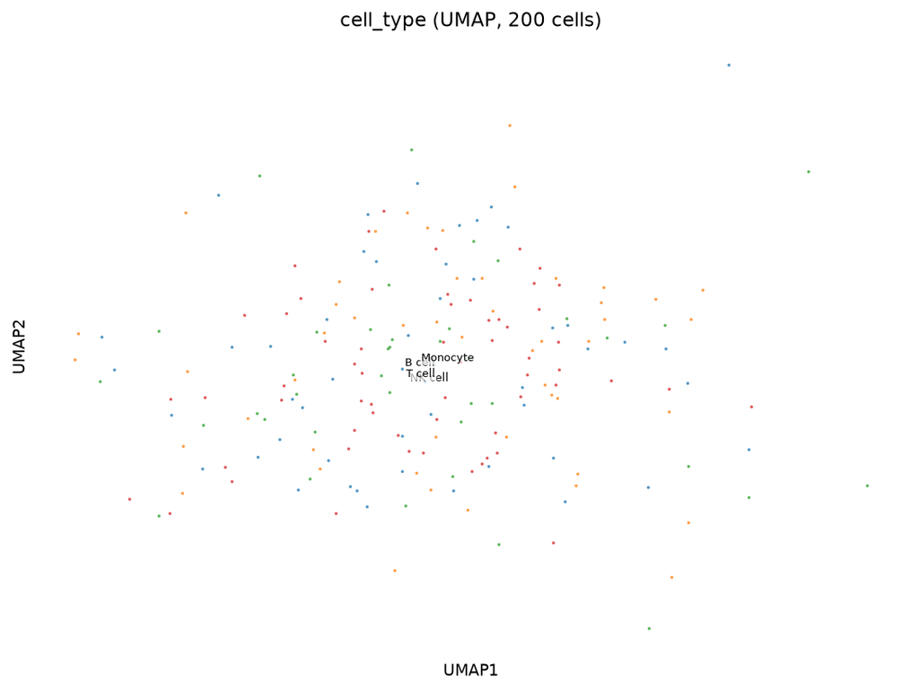

```python
# ── 4.1  default: color by cell type ─────────────────────────────────────
fig = sv.plot_embedding(ds, color="cell_type")
plt.show()
```

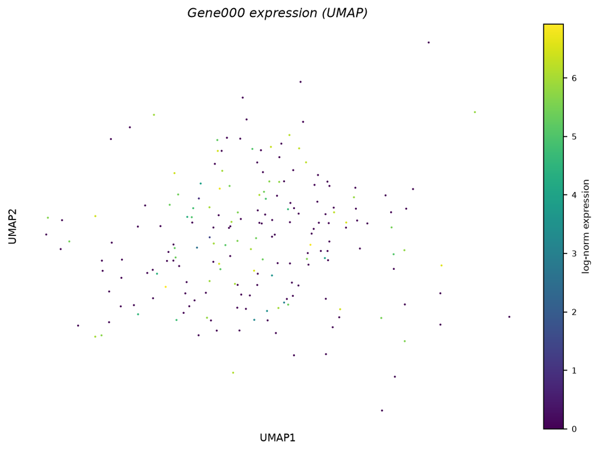

```python
# ── 4.2  color by gene expression ────────────────────────────────────────
fig = sv.plot_embedding(ds, gene="Gene000")
plt.show()
```

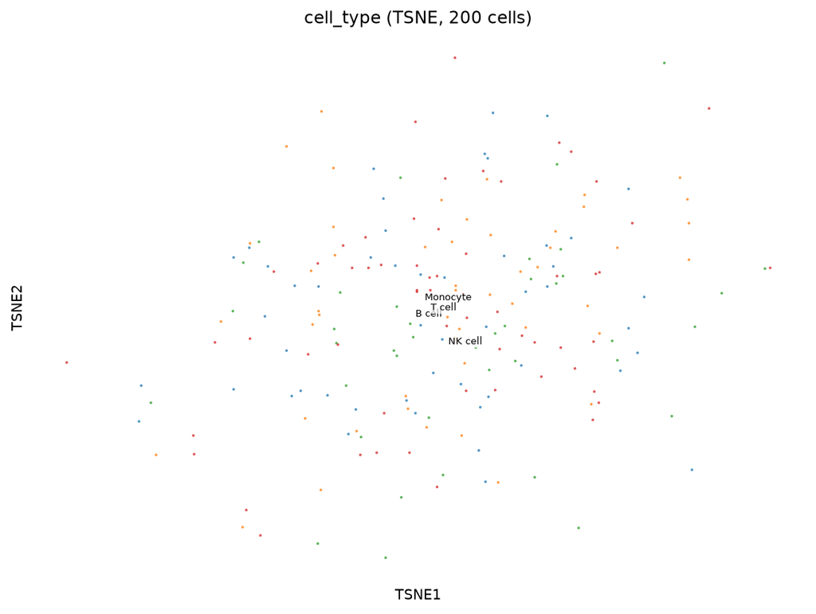

```python
# ── 4.3  t-SNE instead of UMAP ───────────────────────────────────────────
fig = sv.plot_embedding(ds, color="cell_type", embedding="X_tsne")
plt.show()
```

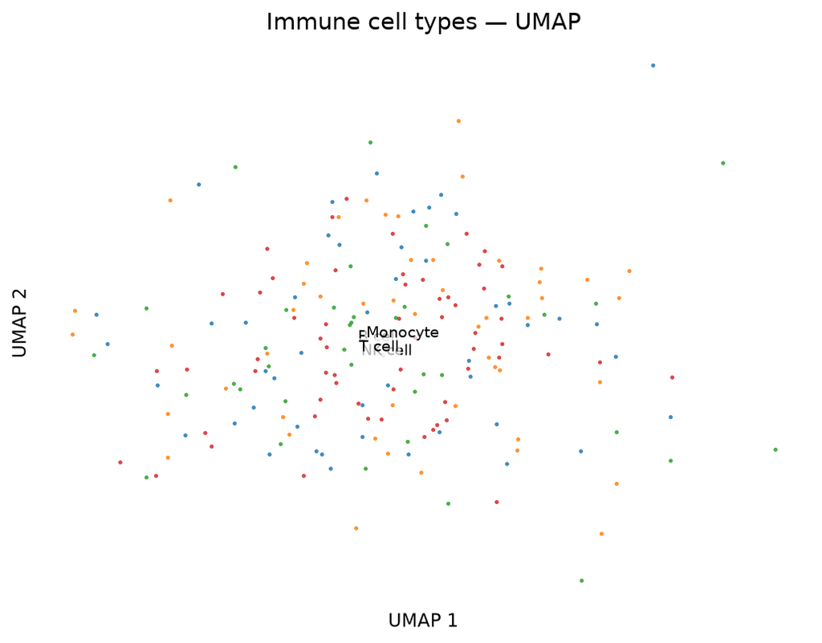

```python
# ── 4.4  full typography control ─────────────────────────────────────────
fig = sv.plot_embedding(
    ds,
    color="cell_type",
    # layout
    figsize=(7, 5.5),
    dpi=150,
    # scatter
    point_size=6,
    alpha=0.85,
    # labels
    title="Immune cell types — UMAP",
    title_fontsize=14,
    label_groups=True,
    label_fontsize=9,
    xlabel="UMAP 1",
    ylabel="UMAP 2",
    xlabel_fontsize=11,
    ylabel_fontsize=11,
    tick_fontsize=9,
    # legend (shown when label_groups=False)
    show_legend=False,
    legend_fontsize=9,
    # font
    font_family="DejaVu Sans",
)
plt.show()
```

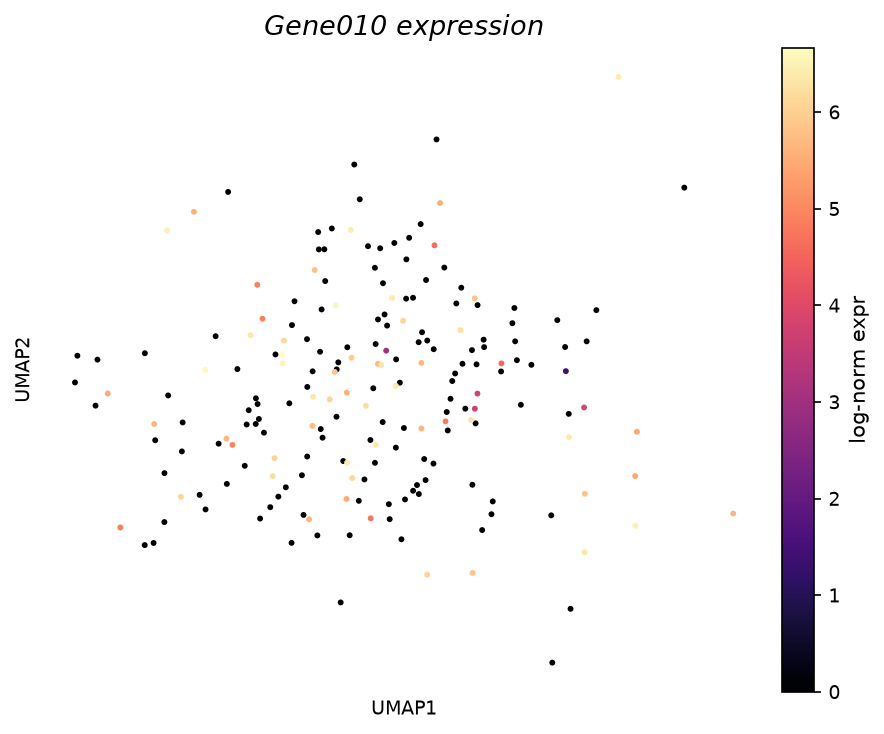

```python
# ── 4.5  gene expression with colorbar customization ─────────────────────
fig = sv.plot_embedding(
    ds,
    gene="Gene010",
    figsize=(6, 5),
    dpi=150,
    cmap="magma",
    point_size=8,
    title="Gene010 expression",
    title_fontsize=13,
    colorbar_label="log-norm expr",
    colorbar_fontsize=10,
)
plt.show()
```

## 5 · `plot_multigene`

Grid of embedding panels, one per gene.

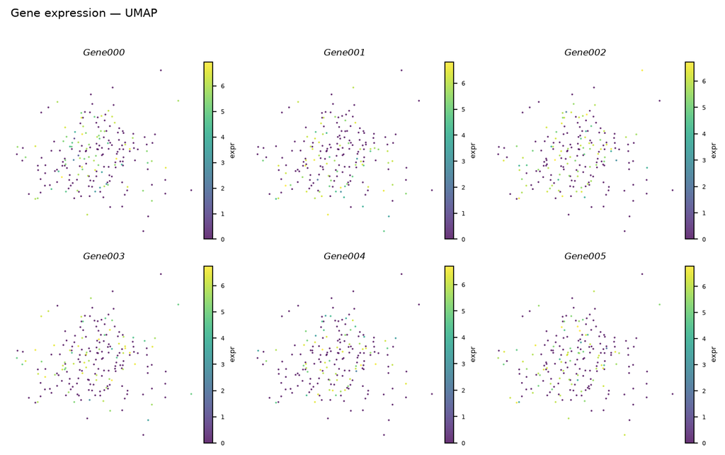

```python
# ── 5.1  default ─────────────────────────────────────────────────────────
top_genes = [f"Gene{i:03d}" for i in range(6)]
fig = sv.plot_multigene(ds, genes=top_genes)
plt.show()
```

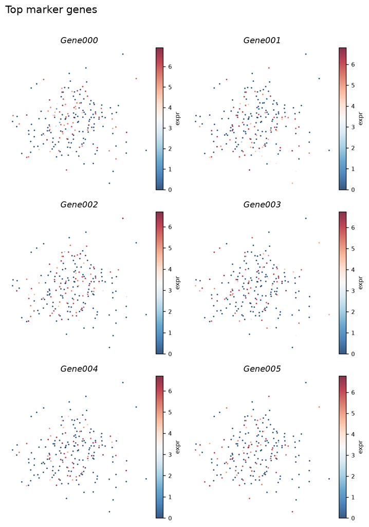

```python
# ── 5.2  2-column layout with custom typography ───────────────────────────
fig = sv.plot_multigene(
    ds,
    genes=top_genes,
    ncol=2,                      # 2-column grid
    figsize=(7, 10),             # override auto-size
    dpi=150,
    point_size=4,
    cmap="RdBu_r",
    suptitle="Top marker genes",
    suptitle_fontsize=14,
    panel_title_fontsize=11,
    colorbar_fontsize=8,
    font_family="DejaVu Sans",
)
plt.show()
```

## 6 · `plot_violin`

Violin or box plot of gene expression per group.

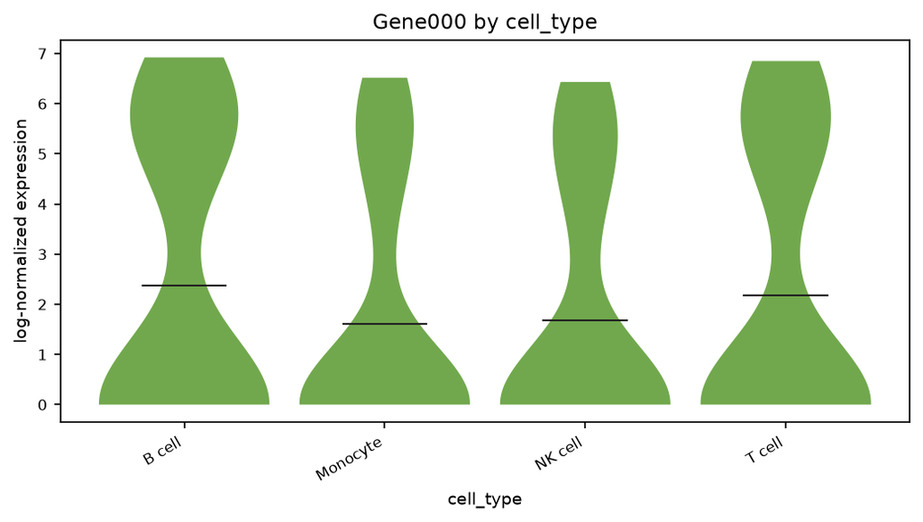

```python
# ── 6.1  default violin ───────────────────────────────────────────────────
fig = sv.plot_violin(ds, gene="Gene000", group="cell_type")
plt.show()
```

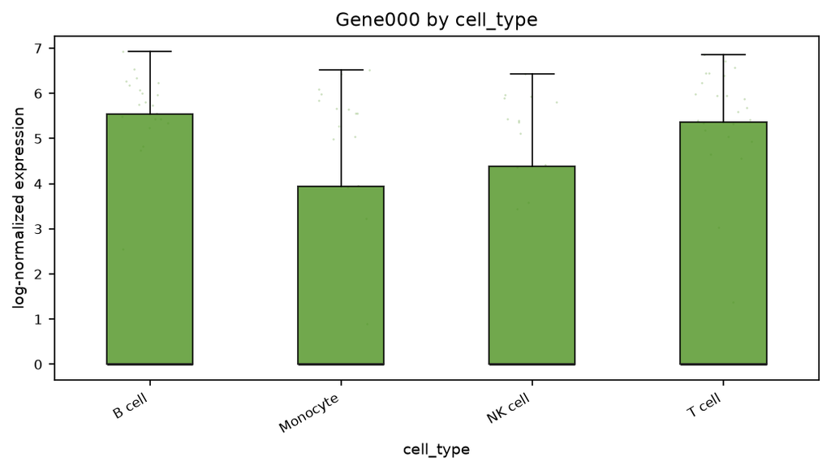

```python
# ── 6.2  box plot with data points ────────────────────────────────────────
fig = sv.plot_violin(
    ds,
    gene="Gene000",
    group="cell_type",
    kind="box",
    show_points=True,
)
plt.show()
```

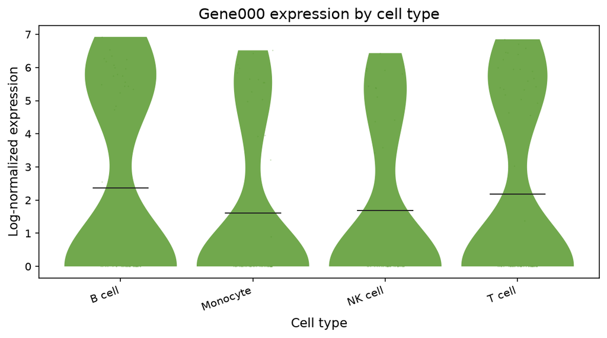

```python
# ── 6.3  publication-quality typography ──────────────────────────────────
fig = sv.plot_violin(
    ds,
    gene="Gene000",
    group="cell_type",
    kind="violin",
    show_points=True,
    # layout
    figsize=(8, 4.5),
    dpi=150,
    # typography
    title="Gene000 expression by cell type",
    title_fontsize=14,
    xlabel="Cell type",
    ylabel="Log-normalized expression",
    xlabel_fontsize=12,
    ylabel_fontsize=12,
    tick_fontsize=10,
    rotation=20,
    font_family="DejaVu Sans",
)
plt.show()
```

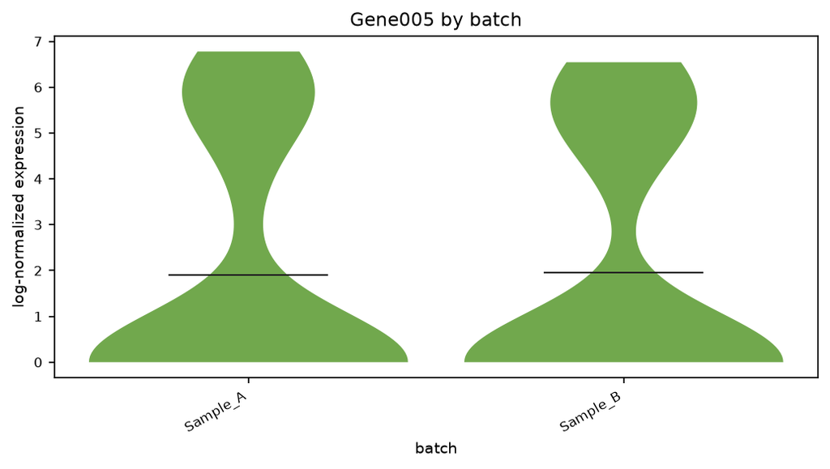

```python
# ── 6.4  split by batch ───────────────────────────────────────────────────
fig = sv.plot_violin(ds, gene="Gene005", group="batch")
plt.show()
```

## 7 · `plot_dotplot`

Dot size = fraction of cells expressing the gene.  
Dot color = mean log-normalized expression.

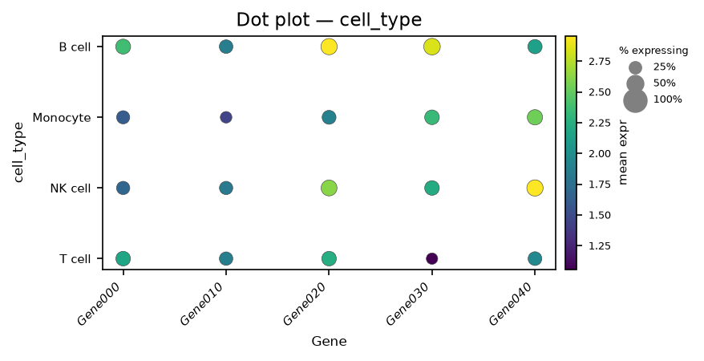

```python
# ── 7.1  default ─────────────────────────────────────────────────────────
marker_genes = [f"Gene{i:03d}" for i in [0, 10, 20, 30, 40]]
fig = sv.plot_dotplot(ds, genes=marker_genes, group="cell_type")
plt.show()
```

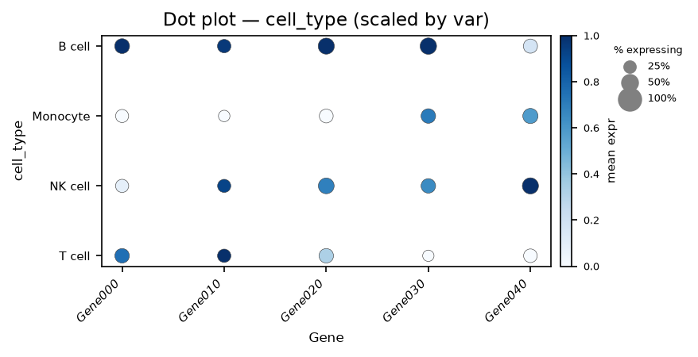

```python
# ── 7.2  scale within each gene (standard_scale="var") ───────────────────
fig = sv.plot_dotplot(
    ds,
    genes=marker_genes,
    group="cell_type",
    standard_scale="var",   # normalize 0-1 per gene column
    cmap="Blues",
)
plt.show()
```

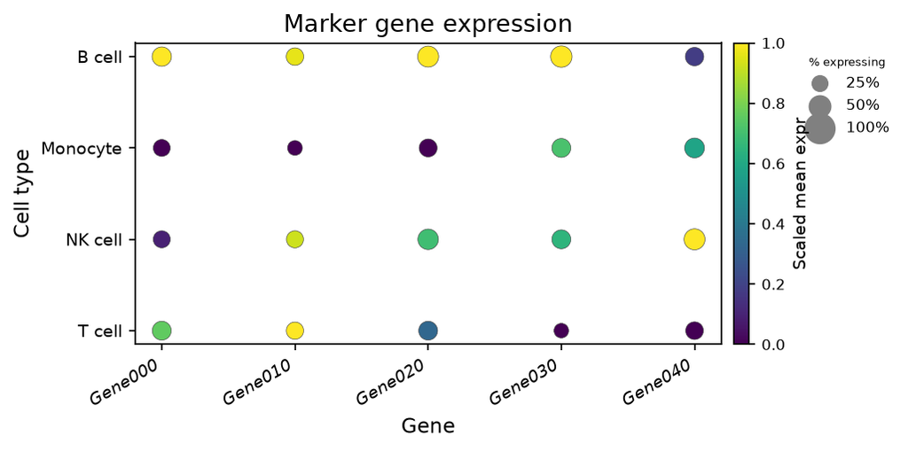

```python
# ── 7.3  full typography control ─────────────────────────────────────────
fig = sv.plot_dotplot(
    ds,
    genes=marker_genes,
    group="cell_type",
    standard_scale="var",
    cmap="viridis",
    size_scale=250,
    # layout
    figsize=(7, 3.5),
    dpi=150,
    # typography
    title="Marker gene expression",
    title_fontsize=13,
    xlabel="Gene",
    ylabel="Cell type",
    xlabel_fontsize=11,
    ylabel_fontsize=11,
    tick_fontsize=9,
    gene_label_rotation=30,
    colorbar_label="Scaled mean expr",
    colorbar_fontsize=9,
    legend_fontsize=8,
    font_family="DejaVu Sans",
)
plt.show()
```

## 8 · `plot_composition`

Stacked bar showing cell-type proportions across samples / conditions.

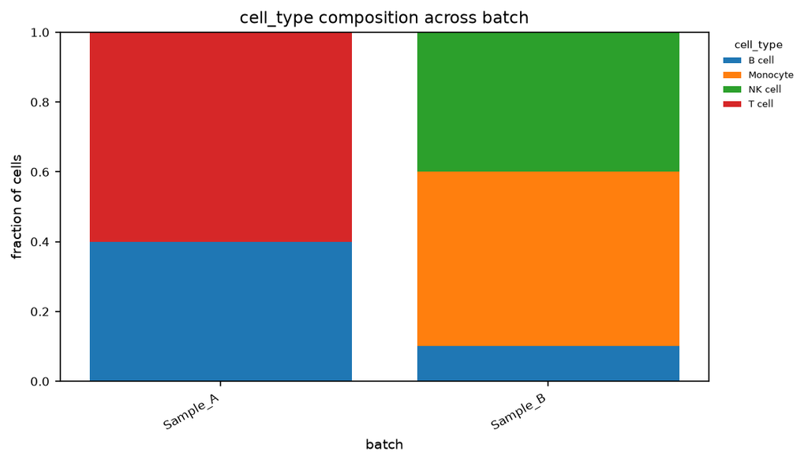

```python
# ── 8.1  default (fraction) ───────────────────────────────────────────────
fig = sv.plot_composition(ds, group="cell_type", split="batch")
plt.show()
```

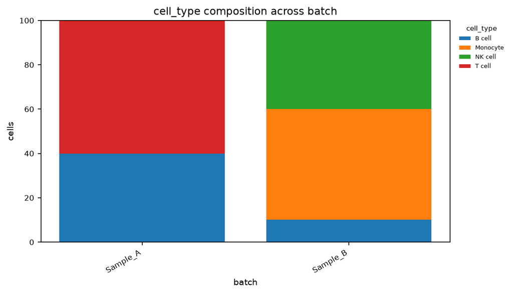

```python
# ── 8.2  raw cell counts ─────────────────────────────────────────────────
fig = sv.plot_composition(ds, group="cell_type", split="batch", normalize=False)
plt.show()
```

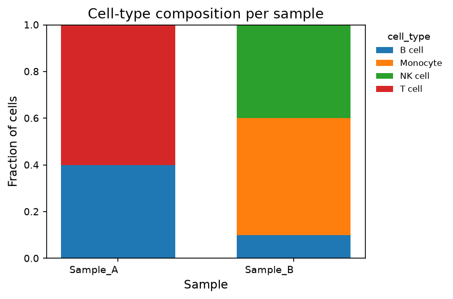

```python
# ── 8.3  full typography control ─────────────────────────────────────────
fig = sv.plot_composition(
    ds,
    group="cell_type",
    split="batch",
    normalize=True,
    sort_groups=True,
    # layout
    figsize=(6, 4),
    dpi=150,
    bar_width=0.65,
    # typography
    title="Cell-type composition per sample",
    title_fontsize=13,
    xlabel="Sample",
    ylabel="Fraction of cells",
    xlabel_fontsize=11,
    ylabel_fontsize=11,
    tick_fontsize=9,
    rotation=0,
    legend_fontsize=8,
    legend_title_fontsize=9,
    font_family="DejaVu Sans",
)
plt.show()
```

## 9 · Table functions

```python
# ── 9.1  marker / DE table ───────────────────────────────────────────────
mk = sv.markers_table(ds, top_n=5)      # top 5 genes per group
print(f"Shape: {mk.shape}")
mk.head(10)
```

```
Shape: (20, 7)
```

|  | gene | group | logfoldchange | pval | pval_adj | rank | score |
| --- | --- | --- | --- | --- | --- | --- | --- |
| 0 | Gene010 | B cell | 2.359001 | 0.048961 | 0.037714 | 1 | 1.208261 |
| 1 | Gene011 | B cell | 2.298281 | 0.019731 | 0.031913 | 2 | 8.988140 |
| 2 | Gene012 | B cell | 2.021853 | 0.020457 | 0.060177 | 3 | 6.228904 |
| 3 | Gene013 | B cell | 2.838453 | 0.009837 | 0.037721 | 4 | 5.208762 |
| 4 | Gene014 | B cell | 1.485267 | 0.008144 | 0.068456 | 5 | 2.179978 |
| 5 | Gene030 | Monocyte | 1.827126 | 0.012240 | 0.016125 | 1 | 3.235658 |
| 6 | Gene031 | Monocyte | 2.850048 | 0.038868 | 0.051766 | 2 | 8.991899 |
| 7 | Gene032 | Monocyte | 1.726520 | 0.026828 | 0.043456 | 3 | 5.767711 |
| 8 | Gene033 | Monocyte | 0.829387 | 0.047612 | 0.048203 | 4 | 2.130975 |
| 9 | Gene034 | Monocyte | 2.883014 | 0.027721 | 0.020772 | 5 | 2.472192 |

```python
# filter to a single cell type
t_markers = sv.markers_table(ds, group="T cell", top_n=5)
t_markers
```

|  | gene | group | logfoldchange | pval | pval_adj | rank | score |
| --- | --- | --- | --- | --- | --- | --- | --- |
| 0 | Gene000 | T cell | 2.026925 | 0.019808 | 0.067762 | 1 | 5.981868 |
| 1 | Gene001 | T cell | 2.314424 | 0.037921 | 0.098342 | 2 | 6.102440 |
| 2 | Gene002 | T cell | 1.548181 | 0.000623 | 0.079603 | 3 | 5.631247 |
| 3 | Gene003 | T cell | 1.800575 | 0.004704 | 0.088966 | 4 | 4.671653 |
| 4 | Gene004 | T cell | 1.487518 | 0.007469 | 0.096155 | 5 | 7.143234 |

```python
# sort by logfoldchange instead of rank
sv.markers_table(ds, sort_by="logfoldchange", ascending=False, top_n=5)
```

|  | gene | group | logfoldchange | pval | pval_adj | rank | score |
| --- | --- | --- | --- | --- | --- | --- | --- |
| 0 | Gene013 | B cell | 2.838453 | 0.009837 | 0.037721 | 4 | 5.208762 |
| 1 | Gene016 | B cell | 2.383761 | 0.013906 | 0.020209 | 7 | 8.929324 |
| 2 | Gene010 | B cell | 2.359001 | 0.048961 | 0.037714 | 1 | 1.208261 |
| 3 | Gene011 | B cell | 2.298281 | 0.019731 | 0.031913 | 2 | 8.988140 |
| 4 | Gene012 | B cell | 2.021853 | 0.020457 | 0.060177 | 3 | 6.228904 |
| 5 | Gene034 | Monocyte | 2.883014 | 0.027721 | 0.020772 | 5 | 2.472192 |
| 6 | Gene031 | Monocyte | 2.850048 | 0.038868 | 0.051766 | 2 | 8.991899 |
| 7 | Gene038 | Monocyte | 2.354037 | 0.007644 | 0.092067 | 9 | 5.218834 |
| 8 | Gene037 | Monocyte | 1.829715 | 0.049430 | 0.081831 | 8 | 2.685151 |
| 9 | Gene030 | Monocyte | 1.827126 | 0.012240 | 0.016125 | 1 | 3.235658 |
| 10 | Gene021 | NK cell | 2.955917 | 0.003591 | 0.013779 | 2 | 9.576992 |
| 11 | Gene027 | NK cell | 2.740305 | 0.013227 | 0.084648 | 8 | 1.903561 |
| 12 | Gene026 | NK cell | 2.430882 | 0.047077 | 0.012066 | 7 | 2.861322 |
| 13 | Gene020 | NK cell | 2.412009 | 0.045082 | 0.098457 | 1 | 8.890397 |
| 14 | Gene029 | NK cell | 2.275613 | 0.043729 | 0.033932 | 10 | 8.662012 |
| 15 | Gene009 | T cell | 2.663931 | 0.004993 | 0.020440 | 10 | 8.182877 |
| 16 | Gene008 | T cell | 2.457400 | 0.005231 | 0.090397 | 9 | 6.129404 |
| 17 | Gene001 | T cell | 2.314424 | 0.037921 | 0.098342 | 2 | 6.102440 |
| 18 | Gene000 | T cell | 2.026925 | 0.019808 | 0.067762 | 1 | 5.981868 |
| 19 | Gene003 | T cell | 1.800575 | 0.004704 | 0.088966 | 4 | 4.671653 |

```python
# ── 9.2  composition table ────────────────────────────────────────────────
comp = sv.composition_table(ds, group="cell_type", split="batch")
comp   # fraction of each cell type per batch
```

| cell_type | batch | B cell | Monocyte | NK cell | T cell |
| --- | --- | --- | --- | --- | --- |
| 0 | Sample_A | 0.4 | 0.0 | 0.0 | 0.6 |
| 1 | Sample_B | 0.1 | 0.5 | 0.4 | 0.0 |

```python
# ── 9.3  metadata table ───────────────────────────────────────────────────
meta = sv.metadata_table(ds)
print(f"Shape: {meta.shape}")
meta.head()
```

```
Shape: (200, 3)
```

|  | cell_type | batch | n_counts |
| --- | --- | --- | --- |
| 0 | T cell | Sample_A | 161.492371 |
| 1 | T cell | Sample_A | 139.741364 |
| 2 | T cell | Sample_A | 163.616516 |
| 3 | T cell | Sample_A | 156.470978 |
| 4 | T cell | Sample_A | 155.458832 |

## 10 · Export figures & tables

```python
# ── 10.1  export all standard figures ─────────────────────────────────────
fig_dir = "/tmp/scpyviewer_figs"

written = sv.export_figures(
    ds,
    outdir=fig_dir,
    formats=["png", "pdf"],      # any of: png, pdf, svg
    dpi=200,
    # apply consistent typography to all exported figures
    title_fontsize=12,
    tick_fontsize=9,
    label_fontsize=10,
    font_family="DejaVu Sans",
)

print("Written files:")
for p in written:
    print(" ", p)
```

```
Written files:
  /tmp/scpyviewer_figs/embedding_group.png
  /tmp/scpyviewer_figs/embedding_group.pdf
  /tmp/scpyviewer_figs/embedding_gene.png
  /tmp/scpyviewer_figs/embedding_gene.pdf
  /tmp/scpyviewer_figs/multigene_grid.png
  /tmp/scpyviewer_figs/multigene_grid.pdf
  /tmp/scpyviewer_figs/violin.png
  /tmp/scpyviewer_figs/violin.pdf
  /tmp/scpyviewer_figs/dotplot.png
  /tmp/scpyviewer_figs/dotplot.pdf
  /tmp/scpyviewer_figs/composition.png
  /tmp/scpyviewer_figs/composition.pdf
```

```
Saved PNG / PDF / SVG
```

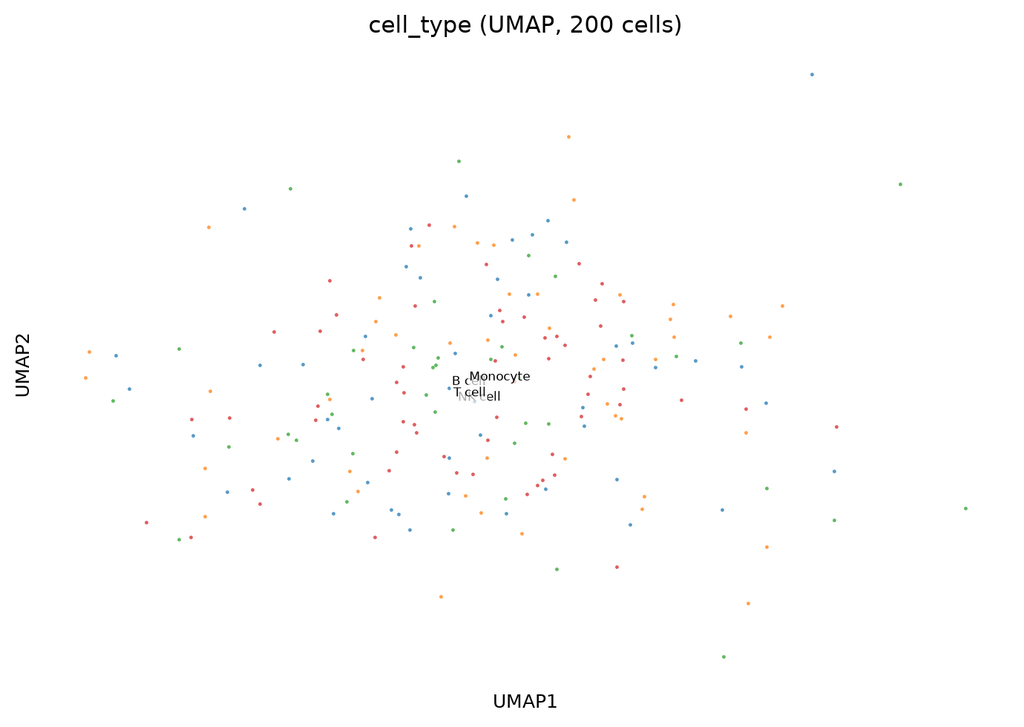

```python
# ── 10.2  save a single figure manually ──────────────────────────────────
fig = sv.plot_embedding(ds, color="cell_type", dpi=200, figsize=(7, 5))
fig.savefig("/tmp/umap_celltypes.png", dpi=200, bbox_inches="tight")
fig.savefig("/tmp/umap_celltypes.pdf",           bbox_inches="tight")
fig.savefig("/tmp/umap_celltypes.svg",           bbox_inches="tight")
print("Saved PNG / PDF / SVG")
```

```python
# ── 10.3  export tables ───────────────────────────────────────────────────
tbl_dir = "/tmp/scpyviewer_tables"

written = sv.export_tables(
    ds,
    outdir=tbl_dir,
    formats=["csv", "tsv"],   # add "xlsx" if openpyxl is installed
    top_n=25,
)

print("Written tables:")
for p in written:
    print(" ", p)
```

```
Written tables:
  /tmp/scpyviewer_tables/markers.csv
  /tmp/scpyviewer_tables/markers.tsv
  /tmp/scpyviewer_tables/composition.csv
  /tmp/scpyviewer_tables/composition.tsv
  /tmp/scpyviewer_tables/metadata.csv
  /tmp/scpyviewer_tables/metadata.tsv
```

## 11 · Publication-quality workflow

A complete example: global style → per-figure fine-tuning → batch export at 300 DPI.

```python
# ── Step 1: apply a global style for the whole analysis ───────────────────
sv.set_style(
    font_family="DejaVu Sans",
    base_fontsize=11,
    dpi=300,
)
```

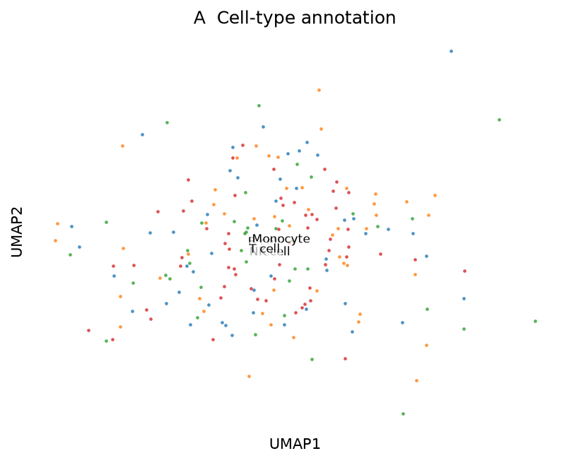

```python
# ── Step 2: UMAP overview for panel A ─────────────────────────────────────
fig_a = sv.plot_embedding(
    ds,
    color="cell_type",
    figsize=(5.5, 4.5),
    point_size=5, alpha=0.8,
    title="A  Cell-type annotation",
    title_fontsize=12,
    label_fontsize=8,
    xlabel_fontsize=10, ylabel_fontsize=10,
    tick_fontsize=8,
)
plt.show()
```

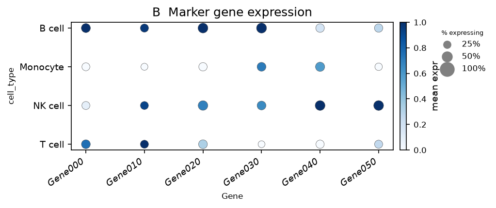

```python
# ── Step 3: dot plot for panel B ──────────────────────────────────────────
fig_b = sv.plot_dotplot(
    ds,
    genes=[f"Gene{i:03d}" for i in [0, 10, 20, 30, 40, 50]],
    group="cell_type",
    standard_scale="var",
    cmap="Blues",
    figsize=(7, 3),
    title="B  Marker gene expression",
    title_fontsize=12,
    tick_fontsize=9,
    colorbar_fontsize=9,
    legend_fontsize=8,
    gene_label_rotation=35,
)
plt.show()
```

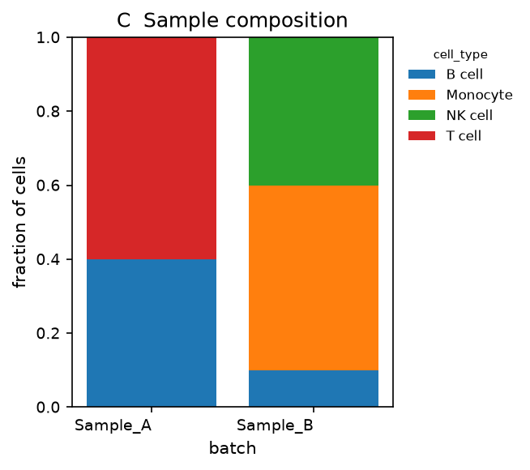

```python
# ── Step 4: composition bar for panel C ───────────────────────────────────
fig_c = sv.plot_composition(
    ds,
    group="cell_type", split="batch",
    figsize=(4.5, 4),
    title="C  Sample composition",
    title_fontsize=12,
    xlabel_fontsize=10, ylabel_fontsize=10,
    tick_fontsize=9, rotation=0,
    legend_fontsize=8,
)
plt.show()
```

```python
# ── Step 5: batch-export all panels at 300 DPI ────────────────────────────
out = "/tmp/paper_figs"
os.makedirs(out, exist_ok=True)

for name, fig in [("panelA_umap", fig_a),
                  ("panelB_dotplot", fig_b),
                  ("panelC_composition", fig_c)]:
    for fmt in ("png", "pdf", "svg"):
        path = os.path.join(out, f"{name}.{fmt}")
        fig.savefig(path, dpi=300, bbox_inches="tight")

print("Exported to", out)
print(os.listdir(out))
```

```
Exported to /tmp/paper_figs
['panelB_dotplot.pdf', 'panelC_composition.svg', 'panelB_dotplot.png', 'panelA_umap.png', 'panelC_composition.pdf', 'panelA_umap.svg', 'panelC_composition.png', 'panelA_umap.pdf', 'panelB_dotplot.svg']
```

## Parameter quick-reference

| Parameter | Type | Applies to | What it controls |
| --- | --- | --- | --- |
| `figsize` | `(float, float)` | all | Figure width × height in inches |
| `dpi` | `int` | all | Resolution (dots per inch) |
| `title` | `str` | all | Figure title text |
| `title_fontsize` | `float` | all | Title font size |
| `xlabel` / `ylabel` | `str` | violin, dotplot, composition, heatmap, matrixplot, stacked_violin, tracksplot | Axis label text |
| `xlabel_fontsize` / `ylabel_fontsize` | `float` | violin, dotplot, composition, heatmap, matrixplot, stacked_violin, tracksplot | Axis label font size |
| `tick_fontsize` | `float` | all | Tick-label font size |
| `legend_fontsize` | `float` | embedding, dotplot, composition | Legend entry font size |
| `colorbar_fontsize` | `float` | embedding (gene), multigene, dotplot, heatmap, matrixplot, tracksplot, correlation | Colorbar text size |
| `label_fontsize` | `float` | embedding | Centroid text label size |
| `panel_title_fontsize` | `float` | multigene | Per-panel title size |
| `suptitle_fontsize` | `float` | multigene | Figure super-title size |
| `gene_label_rotation` | `int` | dotplot | X-axis gene label rotation (°) |
| `gene_label_fontsize` | `float` | stacked_violin | Gene label font size on Y axis |
| `rotation` | `int` | violin, composition | X-tick rotation (°) |
| `font_family` | `str` | all | Per-figure font family |
| `point_size` | `float` | embedding, multigene | Scatter point diameter |
| `alpha` | `float` | embedding, multigene | Point transparency |
| `cmap` | `str` | embedding, multigene, dotplot, heatmap, matrixplot, tracksplot, correlation | Matplotlib colormap |
| `vmin` / `vmax` | `float` | heatmap, matrixplot, tracksplot, correlation | Clip color range |
| `standard_scale` | `str` | dotplot, heatmap, matrixplot | `None`, `"var"`, or `"group"` |
| `swap_axes` | `bool` | heatmap, matrixplot, stacked_violin | Transpose gene/group axes |
| `show_group_bar` | `bool` | heatmap | Show group color strip |
| `annotate` | `bool` | matrixplot, correlation | Overlay numeric values |
| `annotation_fmt` | `str` | matrixplot, correlation | Python format string, e.g. `".2f"` |
| `inner` | `str` | stacked_violin | Violin inner: `"box"`, `"quartile"`, `"point"`, `None` |
| `linewidth` | `float` | stacked_violin | Violin outline width |
| `track_height` | `float` | tracksplot | Height of each gene track (inches) |
| `show_group_labels` | `bool` | tracksplot | Label group boundaries |
| `method` | `str` | correlation | `"pearson"` or `"spearman"` |
| `kind` | `str` | violin | `"violin"` or `"box"` |
| `show_points` | `bool` | violin | Overlay jittered data points |
| `normalize` | `bool` | composition | Fraction vs. raw counts |

*Generated with scPyviewer v0.4.0. See github.com/xuan13hao/scPyviewer for the source.*

## 12 · `plot_heatmap`

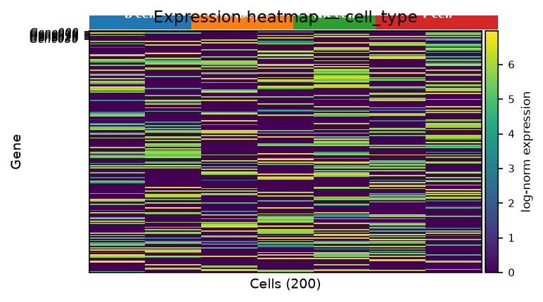

```python
heatmap_genes = [f"Gene{i:03d}" for i in [0, 5, 10, 15, 20, 25, 30]]

# ── 12.1  default: genes (rows) × cell types (columns) ────────────────────
fig = sv.plot_heatmap(ds, genes=heatmap_genes, group="cell_type")
plt.show()
```

[figure not shown]

```python
# ── 12.2  swap axes: cell types (rows) × genes (columns) ──────────────────
fig = sv.plot_heatmap(ds, genes=heatmap_genes, group="cell_type", swap_axes=True)
plt.show()
```

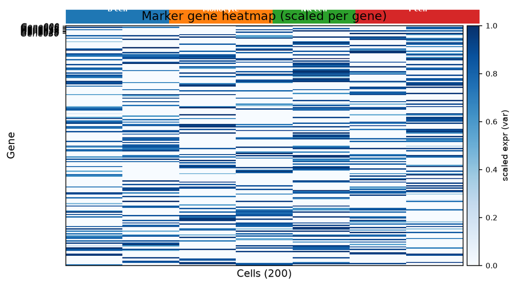

```python
# ── 12.3  scale 0-1 per gene, add group color bar, full typography ─────────
fig = sv.plot_heatmap(
    ds,
    genes=heatmap_genes,
    group="cell_type",
    standard_scale="var",     # normalize each gene 0→1 across groups
    show_group_bar=True,      # color strip above/below
    cmap="Blues",
    # layout
    figsize=(8, 5),
    dpi=150,
    # typography
    title="Marker gene heatmap (scaled per gene)",
    title_fontsize=13,
    xlabel_fontsize=11,
    ylabel_fontsize=11,
    tick_fontsize=9,
    colorbar_fontsize=9,
    font_family="DejaVu Sans",
)
plt.show()
```

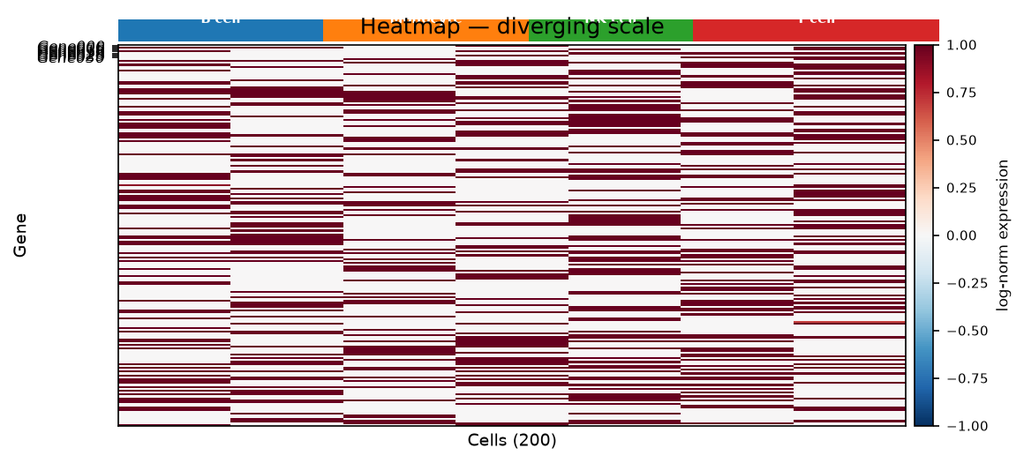

```python
# ── 12.4  diverging colormap with clipped color range ─────────────────────
fig = sv.plot_heatmap(
    ds,
    genes=heatmap_genes,
    group="cell_type",
    cmap="RdBu_r",
    vmin=-1, vmax=1,          # clip color range
    figsize=(8, 4),
    dpi=150,
    title="Heatmap — diverging scale",
    title_fontsize=12,
    tick_fontsize=8,
)
plt.show()
```

## 13 · `plot_matrixplot`

Color-coded grid of **mean expression** per gene per group, optionally annotated with the numeric value.  
Cleaner than Scanpy's matrixplot because annotation font sizes and colorbar labels are fully configurable.

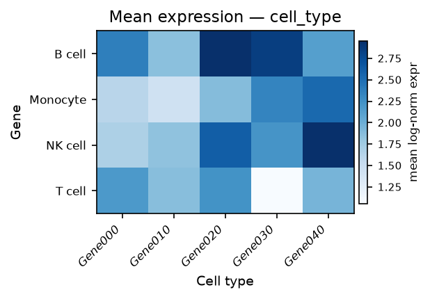

```python
matrix_genes = [f"Gene{i:03d}" for i in [0, 10, 20, 30, 40]]

# ── 13.1  default matrixplot ───────────────────────────────────────────────
fig = sv.plot_matrixplot(ds, genes=matrix_genes, group="cell_type")
plt.show()
```

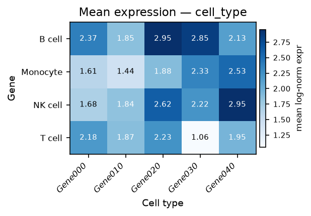

```python
# ── 13.2  with numeric annotations ────────────────────────────────────────
fig = sv.plot_matrixplot(
    ds,
    genes=matrix_genes,
    group="cell_type",
    annotate=True,            # show mean expression value in each cell
    annotation_fmt=".2f",    # two decimal places
)
plt.show()
```

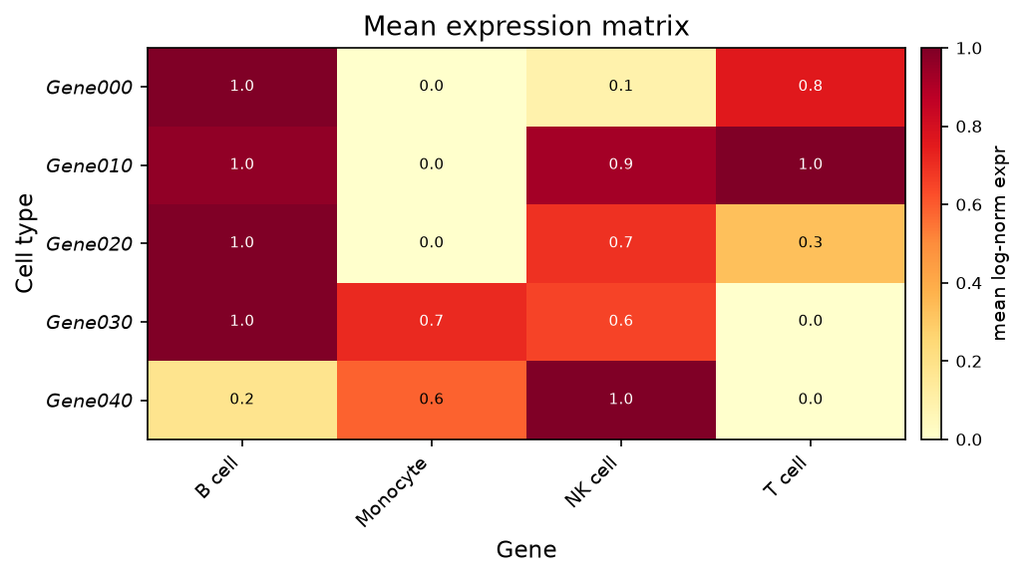

```python
# ── 13.3  swapped axes + full typography ──────────────────────────────────
fig = sv.plot_matrixplot(
    ds,
    genes=matrix_genes,
    group="cell_type",
    swap_axes=True,           # groups on X, genes on Y
    standard_scale="var",
    cmap="YlOrRd",
    annotate=True,
    annotation_fmt=".1f",
    # layout
    figsize=(7, 4),
    dpi=150,
    # typography
    title="Mean expression matrix",
    title_fontsize=13,
    xlabel_fontsize=11,
    ylabel_fontsize=11,
    tick_fontsize=9,
    colorbar_fontsize=9,
    font_family="DejaVu Sans",
)
plt.show()
```